# Lecture #1

평균, 중앙값, 분산, 분위수, 백분위수

Junho Ahn

2022-07-17

`jitter()`함수: 원래 값에 임의의 난수를 더해 난수를 생성

원래 자료는 1~10까지인데 여기에 `jitter()`함수를 적용하여 jittering을 줌

```r
set.seed(12345)

x <- jitter(seq(1,10))
x
```

```
##  [1]  1.088362  2.150309  3.104393  4.154450  4.982592  5.866549  6.930038
##  [8]  8.003690  9.091082 10.195895
```

## 평균

반응: 자료의 합을 자료의 개수로 나눈 값으로 지나치게 큰 값이나 작은 값에 빠르게 반응

계산: `mean()`함수

```r
mean(x)
```

```
## [1] 5.556736
```

## 중앙값

반응: 자료를 크기순으로 나열할 때 **중앙에 위치한 값**으로 지나치게 큰 값이나 작은 값에 늦게 반응함  
개념:  
- 자료의 갯수가 홀수이면 중앙에 한 값이 위치하고 갯수가 짝수이면 중앙에 위치한 두 값의 평균값  
- 중위값, 중위수 등으로도 부름

계산: `mdeian()`함수

```r
median(x)
```

```
## [1] 5.424571
```

### 평균의 오류(평균의 함정)

ex1) 12명의 월급여를 조사하여 얻은 자료를 x1이라 하자.

```r
x1 <- c(200, 170, 250, 230, 220, 300, 350, 300, 330, 260, 270, 250)
x1
```

```
##  [1] 200 170 250 230 220 300 350 300 330 260 270 250
```

이 때의 평균값과 중앙값

```r
mean(x1)
```

```
## [1] 260.8333
```

```r
median(x1)
```

```
## [1] 255
```

ex2) 한 명 더 조사했는데 우연히 그 직장의 CEO가 포함되어 월5000인 자료가 추가 (지나치게 큰 값)되었다고 가정

```r
x2 <- c(x1, 5000)
x2
```

```
##  [1]  200  170  250  230  220  300  350  300  330  260  270  250 5000
```

```r
mean(x2)
```

```
## [1] 625.3846
```

```r
median(x2)
```

```
## [1] 260
```

위 결과에서 보는 것과 같이 중앙값은 크게 변하지 않지만 평균값은 크게 변화함.

## 최빈값

개념: 자료 중 빈도수가 가장 높은 값

계산: native R 내장함수에는 최빈값을 계산하는 함수가 없으므로 몇 개의 함수를 연속적으로 사용

1. 자료와 빈도표: 자료가 있을 때 `table()`함수로 빈도표를 구함

```r
x <- c("A", "B", "C", "D", "B", "C", "D", "C", "D", "D")
table(x)
```

```
## x
## A B C D
## 1 2 3 4
```

2. 빈도표를 순서대로 (decreasing = TRUE, 내림차순)으로 정리함

```r
sort(table(x), decreasing = TRUE)
```

```
## x
## D C B A
## 4 3 2 1
```

3. 빈도푱의 역순에서 가장 처음 나오는 값이 가장 빈도가 높으므로 [1]을 사용하여 첫번째 값을 선택

```r
sort(table(x), decreasing = TRUE)[1]
```

```
## D
## 4
```

4. 빈도표에서 가장 자주 나온 것의 이름을 찾았으므로 이 값에서 값의 header를 찾으면 이 값이 최빈값임

```r
names(sort(table(x), decreasing=TRUE))[1]
```

```
## [1] "D"
```

동일하게 아래의 방법으로도 구할 수 있음.

1. `which.max()`함수를 사용하여 Table내에서 최댓값을 검색

```r
which.max(table(x))
```

```
## D
## 4
```

2. 동일한 방식으로 최댓값의 header를 찾음

```r
names(which.max(table(x)))
```

```
## [1] "D"
```

### 최빈값 계산 예제

```r
BMI <- read.table(url("http://jupiter.hallym.ac.kr/ftpdata/data/bmi.txt"),
                  col.names = c("height", "weight", "year", "religion", "gender", "marriage"))

head(BMI)
```

|  | height | weight | year | religion | gender | marriage |
| --- | --- | --- | --- | --- | --- | --- |
| 1 | 167 | 68 | 1974 | No | F | N |
| 2 | 162 | 49 | 1974 | C2 | F | N |
| 3 | 158 | 50 | 1978 | C2 | F | N |
| 4 | 165 | 56 | 1977 | No | F | N |
| 5 | 160 | 52 | 1959 | No | F | N |
| 6 | 162 | 52 | 1972 | No | F | Y |

이후에 링크가 끊겨 데이터를 사용할 수 없을 수 있어 예비용으로 만들어 둠.

```r
write.csv(BMI, "Lecture01_BMI.csv")
```

BMI dataset은 2000년 177명에 대한 조사 결과를 정리한 dataset임.

- 키, 몸무게, 출생년도
- 종교(Bu=불교, C1=개신교, C2=카톨릭, No=없음)
- 성별(F=여자, M=남자)
- 결혼여부(N=미혼, Y=기혼)

```r
dim(BMI)
```

```
## [1] 177   6
```

예를 들어 종교(religion)에 대한 최빈값을 구하려면,

```r
names(sort(table(BMI$religion), decreasing = TRUE))[1]
```

```
## [1] "No"
```

## 중심의 이동과 기울어짐의 변화에 따른 값의 변화

### 중심의 이동에 따른 값의 변화

반응: 원자료에 특정한 값을 더하거나 빼주면 더하거나 빼준만큼 평균, 중앙값도 함께 이동

계산

```r
set.seed(12345)

x <- jitter(seq(1,10))
x
```

```
##  [1]  1.088362  2.150309  3.104393  4.154450  4.982592  5.866549  6.930038
##  [8]  8.003690  9.091082 10.195895
```

```r
y <- x+3
y
```

```
##  [1]  4.088362  5.150309  6.104393  7.154450  7.982592  8.866549  9.930038
##  [8] 11.003690 12.091082 13.195895
```

```r
mean(x)
```

```
## [1] 5.556736
```

```r
mean(y)
```

```
## [1] 8.556736
```

```r
median(x)
```

```
## [1] 5.424571
```

```r
median(y)
```

```
## [1] 8.424571
```

x에 3을 더한 벡터를 y라고 했을 때, y의 평균과 중앙값은 정확하게 3만큼 증가함을 확인.

```r
mean(y) - mean(x)
```

```
## [1] 3
```

```r
median(y) - median(x)
```

```
## [1] 3
```

### 중심의 기울어짐에 따른 값의 변화

반응: - 자료가 오른쪽 또는 왼쪽으로 기울어진 경우(skewed to the right/left) 평균이 지나치게 큰 값이나 작은 값에 예민하므로 먼저 반응하고, 중앙값은 그 보다 느리게 반응  
- 여기서는 분포의 기울어짐에 따라 평균과 중앙값이 어떻게 달라지는지 확인함.

#### 오른쪽으로 기울어진 분포의 경우: 지나치게 큰 값이 존재하는 경우

카이제곱분포를 만드는 `rchisq()`함수를 사용하여 자유도 5인 카이제곱분포에서 난수 100개를 생성 $\rightarrow$ 이 분포는 오른쪽으로 기울어진 분포

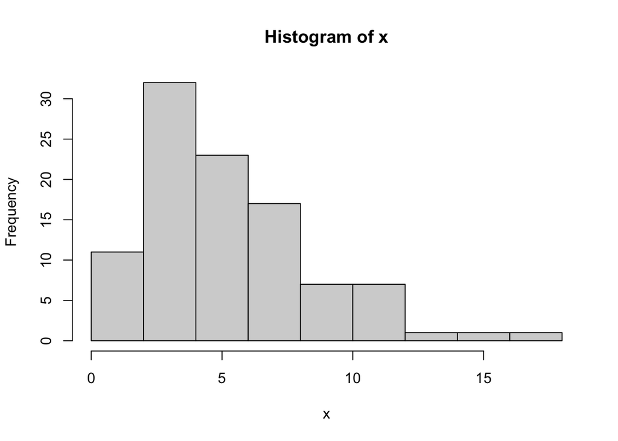

```r
x <- rchisq(100,5)
hist(x)
```

**오른쪽으로 기울어진(skewed to the right) 분포에서는 평균이 중앙값보다 크게 얻어짐**  
평균이 더 빨리 오른쪽으로 간다고 생각하면 이해하기 쉬움

```r
mean(x)
```

```
## [1] 5.236273
```

```r
median(x)
```

```
## [1] 4.888836
```

#### 왼쪽으로 기울어진 분포의 경우: 지나치게 작은 값이 존재하는 경우

자유도 5인 카이제곱분포에서 난수 100개를 생성하여 30에서 이 난수들을 빼면 이 분포는 왼쪽으로 기울어진 분포로 나타남.

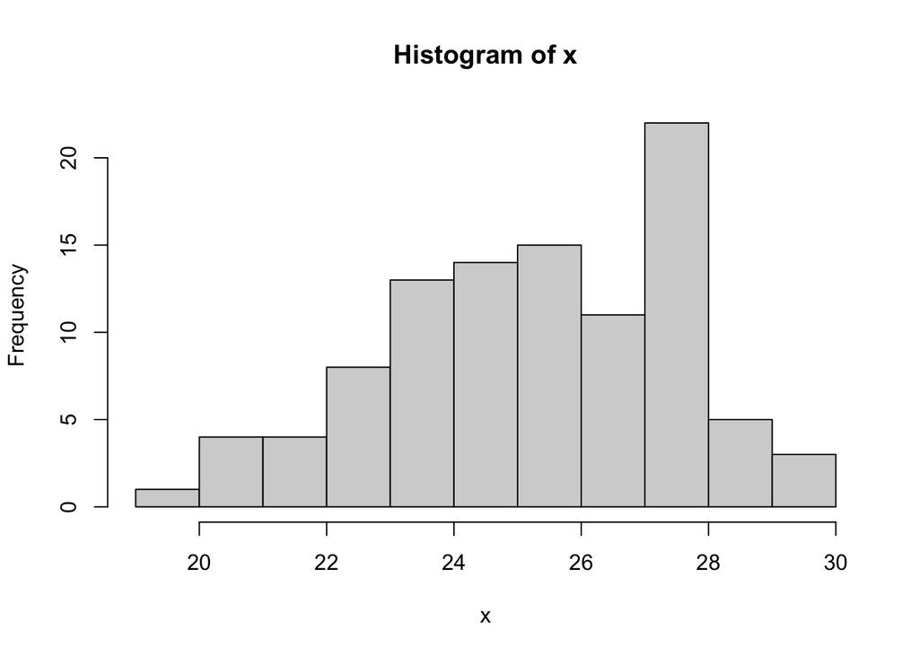

```r
x <- 30 - rchisq(100, 5)
hist(x)
```

```r
mean(x)
```

```
## [1] 25.28887
```

```r
median(x)
```

```
## [1] 25.3886
```

**왼쪽으로 기울어진(skewed to the left) 분포에서는 평균이 중앙값보다 작게 얻어짐**  
평균이 더 빨리 왼쪽으로 간다고 생각하면 이해하기 쉬움

## 분위수(quantile)

### 분위수에 대한 통계학적 엄밀한 정의

- 어떤 값 x에 대해 x보다 같거나 작을 확률을 p이상, x보다 같거나 클 확률은 (1-p)이상인 값 x를 제p번째 분위수라고 함.
- 직관적으로는 자료를 오름차순으로 정리할 때 p번째에 해당하는 값 (0 < p < 1)

### 백분위수(percentile)

- 분위수를 백분위로 바꾼 100p%에 해당하는 값

R에서는 `quantile()`를 사용하여 분위수를 계산할 수 있음.

> quantile(x, probs = seq(0, 1, 0.25), …)
- 매개변수:
  - x: 분위수를 계산할 자료를 포함한 벡터
  - probs: 분위의 값으로 기본값은 c(0, 0.25, 0.5, 0.75, 1.00)으로 최소, 25%, 50%(중앙값; 중위수), 75% 및 최댓값으로 설정

R에서 난수를 생성하는 방법은 크게 두 가지인데 하나는 `sample()`함수를 사용하는 방법이 있고, 다른 하나는 정규분포에서 난수를 생성하는 `rnorm()`함수가 있다. 여기서는 `sample()`을 이용하여 vector를 만들어 `quantile()`함수의 작동을 확인함.

```r
set.seed(2345)
x <- sample(x=1:100, 50) # 1 ~ 100 사이 숫자에서 50개를 무작위 추출
x
```

```
##  [1] 99 83 34 79 76 91 67 66 73 52 65 22 21 49 41 85 36 20 59  8 81 44 16 25 82
## [26]  2 58 43 56 27 90 17 54 10 35 93 23 50 80  4 19 86 61 28 95 39 45 70 98 78
```

```r
quantile(x, probs = seq(0, 1, 0.25))
```

```
##    0%   25%   50%   75%  100%
##  2.00 27.25 53.00 78.75 99.00
```

```r
x <- seq(1,100)
x
```

```
##   [1]   1   2   3   4   5   6   7   8   9  10  11  12  13  14  15  16  17  18
##  [19]  19  20  21  22  23  24  25  26  27  28  29  30  31  32  33  34  35  36
##  [37]  37  38  39  40  41  42  43  44  45  46  47  48  49  50  51  52  53  54
##  [55]  55  56  57  58  59  60  61  62  63  64  65  66  67  68  69  70  71  72
##  [73]  73  74  75  76  77  78  79  80  81  82  83  84  85  86  87  88  89  90
##  [91]  91  92  93  94  95  96  97  98  99 100
```

아무런 매개변수를 설정하지 않으면 기본값으로 출력

```r
quantile(x)
```

```
##     0%    25%    50%    75%   100%
##   1.00  25.75  50.50  75.25 100.00
```

분위수에 기본값 뿐만 아니라 원하는 구역의 값을 찾을 수도 있음

```r
quantile(x, probs = c(0.05, 0.95))
```

```
##    5%   95%
##  5.95 95.05
```

## 흩어짐에 대한 측도

### 분산과 표준편차

분산은 `var()`함수를 사용하고 표준편차는 `sd()`함수를 사용함.

```r
x <- seq(1,10)
x
```

```
##  [1]  1  2  3  4  5  6  7  8  9 10
```

```r
var(x)
```

```
## [1] 9.166667
```

```r
sd(x)
```

```
## [1] 3.02765
```

### 범위

범위는 최대와 최소의 차이로 `range()` 함수나 `max()`와 `min()`함수를 동시에 사용하여 계산함

```r
x <- seq(1,100)
x
```

```
##   [1]   1   2   3   4   5   6   7   8   9  10  11  12  13  14  15  16  17  18
##  [19]  19  20  21  22  23  24  25  26  27  28  29  30  31  32  33  34  35  36
##  [37]  37  38  39  40  41  42  43  44  45  46  47  48  49  50  51  52  53  54
##  [55]  55  56  57  58  59  60  61  62  63  64  65  66  67  68  69  70  71  72
##  [73]  73  74  75  76  77  78  79  80  81  82  83  84  85  86  87  88  89  90
##  [91]  91  92  93  94  95  96  97  98  99 100
```

`range()`함수는 최소와 최대를 한 번에 얻어주며 이 차이를 계산하지는 않음

```r
range(x)
```

```
## [1]   1 100
```

```r
c(max(x), min(x), max(x)-min(x))
```

```
## [1] 100   1  99
```

범위의 2번째 값(최댓값) - 범위의 1번째 값(최솟값)

```r
range(x)[2] - range(x)[1]
```

```
## [1] 99
```

### IQR과 CV(변동계수: Coefficient of Variation)

#### 사분위수(quartiles)

| 사분위수 | 제1사분위수 | 제2사분위수 | 제3사분위수 |
| --- | --- | --- | --- |
| 해당 백분위 | 제25번째 백분위 | 제50번째 백분위 | 제75번째 백분위 |

* 앞에서 본 quantile() 함수는 기본값으로 최솟값, 제1사분위수, 제2사분위수, 제3사분위수 및 최댓값을 얻게 됨.

#### 사분위수 범위(IQR: InterQuartile Range)

- 제3사분위수와 제1사분위수의 차이
- `IQR()`함수를 사용하여 계산함

```r
x <- seq(1,100)
x
```

```
##   [1]   1   2   3   4   5   6   7   8   9  10  11  12  13  14  15  16  17  18
##  [19]  19  20  21  22  23  24  25  26  27  28  29  30  31  32  33  34  35  36
##  [37]  37  38  39  40  41  42  43  44  45  46  47  48  49  50  51  52  53  54
##  [55]  55  56  57  58  59  60  61  62  63  64  65  66  67  68  69  70  71  72
##  [73]  73  74  75  76  77  78  79  80  81  82  83  84  85  86  87  88  89  90
##  [91]  91  92  93  94  95  96  97  98  99 100
```

```r
quantile(x)
```

```
##     0%    25%    50%    75%   100%
##   1.00  25.75  50.50  75.25 100.00
```

```r
quantile(x, probs = c(0.75, 0.25))
```

```
##   75%   25%
## 75.25 25.75
```

```r
IQR(x)
```

```
## [1] 49.5
```

#### 변동계수

- 표준편차를 평균으로 나눈 후 100을 곱한 값

$$CV = \frac{\sigma}{\mu}$$

- 원래의 측정단위가 아예 다르거나 원자료의 크기 차이가 많이 나는 경우에 사용하면 합리적인 결과를 얻음
- 변동계수를 한번에 계산하는 native R함수가 없으므로 아래와 같이 계산해야 함.

```r
sd(x)/mean(x)*100
```

```
## [1] 57.4485
```

ex) ‘주식의 변동계수’ 계산 사례

다음은 두 회사 주식의 7영업일간의 종가이다.  
어느 주식의 변동성이 높다고 할 수 있는가?

```r
stock1 <- c(100000, 107000, 113000, 95000, 103000, 98000, 95000)
stock2 <- c(1000, 900, 1100, 1200, 1000, 800, 700)
```

계산의 편의를 위해 함수 작성

```r
CV <- function(var) {
  sd(var)/mean(var)*100
}
```

```r
CV1 <- CV(stock1)
CV1
```

```
## [1] 6.527091
```

```r
CV2 <- CV(stock2)
CV2
```

```
## [1] 17.95186
```

두 주식의 CV값을 비교해보면 주식1보다 주식2가 변동계수가 더 크기 때문에 주식2의 변동성이 더 크다고 볼 수 있다.

변동계수를 쉽게 계산하려면 `raster` package에 포함된 `cv()` 함수를 사용하면 됨.

```r
library(raster)
cv(seq(1,100))
```

```
## [1] 57.4485
```

## 결측치에 대한 옵션

### na.rm 옵션

자료에 결측치(NA)가 있는 경우

- na.rm옵션에 TRUE를 설정하면 결측치를 제외한 값으로 계산 (rm = ReMove)
- 자료에 NA가 있으면 평균(분산, 중앙값도 마찬가지) 결과는 NA가 얻어짐

```r
x <- c(seq(1,100), NA)
mean(x)
```

```
## [1] NA
```

- 결측치를 제외하고 평균을 얻을 수 있음

```r
mean(x, na.rm=TRUE)
```

```
## [1] 50.5
```

## 가중평균

자료값 $X_i$에 대한 가중치가 $W_i$인 경우

$$\frac{\sum X_i \times W_i}{\sum
W_i}$$

R에서 가중평균은 `weighted.mean()` 함수를 사용

예시) 성적의 가중평균 계산

```r
student1 <- c(90, 80, 70, 90, 95)
student2 <- c(85, 85, 85, 80, 90)
```

```r
mean(student1)
```

```
## [1] 85
```

```r
mean(student2)
```

```
## [1] 85
```

단순평균은 두 학생이 동일한 것을 확인할 수 있음.

각 과목별 가중치를 적용하면,

```r
w <- c(25, 25, 25, 12.5, 12.5)/100
```

학생1의 가중평균점수는

```r
weighted.mean(student1, w)
```

```
## [1] 83.125
```

학생2의 가중평균점수는

```r
weighted.mean(student2, w)
```

```
## [1] 85
```

로 학생2의 가중평균점수가 더 높음을 확인할 수 있다.

```r
sum(student1*w)/sum(w)
```

```
## [1] 83.125
```

```r
sum(student2*w)/sum(w)
```

```
## [1] 85
```

직접 계산한 가중평균점수도 동일하게 나타남을 확인할 수 있음.